# 2019-nCoV Wuhan pneumonia prediction

```python
from IPython.display import HTML
HTML('''<script>
code_show=true;
function code_toggle() {
  if (code_show){
    $(\'div.input\').hide();
  } else {
    $(\'div.input\').show();
  }
  code_show = !code_show
}
$( document ).ready(code_toggle);
</script>
  <form action="javascript:code_toggle()">
    <input type="submit" value="Click here to toggle on/off the code.">
 </form>''')
```

```python
### Import Library
import numpy as np
import pandas as pd

import altair as alt
import matplotlib.pyplot as plt
import seaborn as sns
sns.set_style("darkgrid")
%matplotlib inline

import plotly.offline as py
from plotly.offline import iplot, init_notebook_mode
import plotly.graph_objs as go
py.init_notebook_mode(connected = True)

import os
for dirname, _, filenames in os.walk('/kaggle/input'):
    for filename in filenames:
        print(os.path.join(dirname, filename))
```

```python
df = pd.read_csv('./2019_nCoV_data.csv')
```

```python
df['Date'] = pd.to_datetime(df['Date'])
df['Last Update'] = pd.to_datetime(df['Last Update'])
```

```python
df['Month'] = df['Date'].apply(lambda x:x.month)
df['Day1'] = df['Date'].apply(lambda x:x.day)
df['Hour'] = df['Date'].apply(lambda x:x.hour)
```

```python
df['Day'] = df['Month']*100+df['Day1']
df['Day'] = df['Day'].apply(lambda x:x-100 if x<200 else x-169)
```

```python
#pd.set_option('display.max_columns', None);pd.set_option('display.max_rows', None);df
```

```python
from IPython.display import Markdown
def bold(string):
    display(Markdown(string))
#bold("** Recent 2019-nCoV confirmed cases report **")
from datetime import date
data_2_feb = df[df['Date'] > pd.Timestamp(date(2020,2,4))]
#data_2_feb.head()
```

## 2019-nCoV (武漢肺炎) Analysis and Prediction

> **Source of Data:** World Health Organisation (**WHO**), Centers for Disease Control and Prevention (**CDC**)

> **Predict Model:** Seq2Seq (Sequence to Sequence)

> **Training Result:** Validation Score: **0.0194** MSE (**0.1394** RMSE ), **93.75%** ACC

> **Predict:**: The infection forecast for the next three days is **28348**, **33723**, **37397** (2/6,2/7,2/8). The actual number of people infected with the 2019-nCoV in the world will reach **50,000 at 02/13**

[figure not shown]

```python
# https://cepi.net/wp-content/uploads/2020/01/Novel-coronavirus-post.jpg
# https://www.sciencealert.com/images/2020-01/processed/coronavirus_topic_header_1024.jpg
```

### Prediction Result

- The infection forecast for the next three days is **28348**, **33723**, **37397** (2/6,2/7,2/8)
- The actual number of people infected with the 2019-nCoV in the world will reach **50,000 at 02/13**

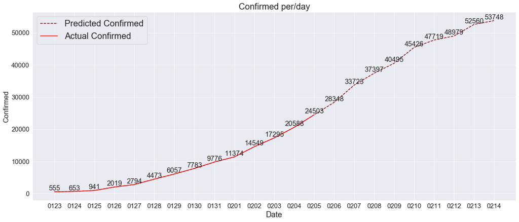

```python
day = ['0123','0124','0125','0126','0127','0128','0129','0130','0131'
       ,'0201','0202','0203','0204','0205','0206','0207','0208','0209','0210'
       ,'0211','0212','0213','0214']
#dfx = pd.DataFrame(data=[y_validate[:], validate_predict])
#dfx = dfx.T
#dfx
plt.figure(figsize=(20, 8))
plt.plot(day,next_confirmed,color='maroon',ls='--',clip_on=True,label='Predicted Confirmed')
plt.plot(BACK_confirmed,color='red',clip_on=True,label='Actual Confirmed')
plt.legend(fontsize=20)
plt.title("Confirmed per/day",fontsize=20)
plt.xlabel('Date', fontsize=18)
plt.ylabel('Confirmed', fontsize=16)
plt.xticks(fontsize=15)
plt.yticks(fontsize=15)

for a, b in zip(day, next_confirmed):
    plt.text(a, b, b, ha='center', va='bottom', fontsize=16)

plt.show()
```

### 1. 2019-nCov Global Status

```python
from IPython.display import IFrame
IFrame('https://datastudio.google.com/embed/reporting/c84945c0-21a5-42ee-bd79-e6e02dfa43c6/page/eHUDB', width='100%', height=1024)
```

[interactive chart not shown]

### Global Heat Map of 2019-nCoV

```python
from IPython.display import IFrame
IFrame('https://kiang.github.io/2019-nCoV/', width=800, height=600)
```

[interactive chart not shown]

### 世界各國感染死亡分布

```python
#bold('**世界各國感染死亡分布**')
temp = data_2_feb.groupby('Country')['Confirmed','Deaths','Recovered'].sum().reset_index().sort_values(by='Confirmed', ascending=False)

cm = sns.light_palette("green", as_cmap=True)

# Set CSS properties for th elements in dataframe
th_props = [
  ('font-size', '11px'),
  ('text-align', 'center'),
  ('font-weight', 'bold'),
  ('color', '#6d6d6d'),
  ('background-color', '#f7f7f9')
  ]

## Set CSS properties for td elements in dataframe
td_props = [
  ('font-size', '11px'),
  ('color', 'black')
   ]

# Set table styles
styles = [
  dict(selector="th", props=th_props),
  dict(selector="td", props=td_props)
  ]

(temp.style
  .background_gradient(cmap=cm, subset=["Confirmed","Deaths","Recovered"])
  .highlight_max(subset=["Confirmed","Deaths","Recovered"])
  #.set_caption('*China Have most confirmed, deaths & recovered cases.')
  .set_table_styles(styles))
```

|  | Country | Confirmed | Deaths | Recovered |
| --- | --- | --- | --- | --- |
| 12 | Mainland China | 24290 | 490 | 890 |
| 23 | Thailand | 25 | 0 | 5 |
| 17 | Singapore | 24 | 0 | 0 |
| 10 | Japan | 22 | 0 | 1 |
| 7 | Hong Kong | 18 | 1 | 0 |
| 18 | South Korea | 16 | 0 | 0 |
| 0 | Australia | 13 | 0 | 2 |
| 6 | Germany | 12 | 0 | 0 |
| 25 | US | 11 | 0 | 0 |
| 22 | Taiwan | 11 | 0 | 0 |
| 13 | Malaysia | 10 | 0 | 0 |
| 11 | Macau | 10 | 0 | 0 |
| 27 | Vietnam | 8 | 0 | 1 |
| 5 | France | 6 | 0 | 0 |
| 26 | United Arab Emirates | 5 | 0 | 0 |
| 3 | Canada | 4 | 0 | 0 |
| 8 | India | 3 | 0 | 0 |
| 9 | Italy | 2 | 0 | 0 |
| 15 | Philippines | 2 | 1 | 0 |
| 16 | Russia | 2 | 0 | 0 |
| 24 | UK | 2 | 0 | 0 |
| 1 | Belgium | 1 | 0 | 0 |
| 19 | Spain | 1 | 0 | 0 |
| 20 | Sri Lanka | 1 | 0 | 0 |
| 21 | Sweden | 1 | 0 | 0 |
| 4 | Finland | 1 | 0 | 0 |
| 2 | Cambodia | 1 | 0 | 0 |
| 14 | Nepal | 1 | 0 | 0 |

### 中國各省感染死亡分布

```python
china_2_feb = data_2_feb[data_2_feb['Country']=='Mainland China'][["Province/State","Confirmed","Deaths","Recovered"]]

#bold("**中國各省感染死亡分布**")

cm = sns.light_palette("green", as_cmap=True)

th_props = [
  ('font-size', '11px'),
  ('text-align', 'center'),
  ('font-weight', 'bold'),
  ('color', '#6d6d6d'),
  ('background-color', '#f7f7f9')
  ]

td_props = [
  ('font-size', '11px'),
  ('color', 'black')
   ]

styles = [
  dict(selector="th", props=th_props),
  dict(selector="td", props=td_props)
  ]

(china_2_feb.style
  .background_gradient(cmap=cm, subset=["Confirmed","Deaths","Recovered"])
  .highlight_max(subset=["Confirmed","Deaths","Recovered"])
  .set_table_styles(styles))
```

|  | Province/State | Confirmed | Deaths | Recovered |
| --- | --- | --- | --- | --- |
| 700 | Hubei | 16678 | 479 | 522 |
| 701 | Zhejiang | 895 | 0 | 63 |
| 702 | Guangdong | 870 | 0 | 32 |
| 703 | Henan | 764 | 2 | 41 |
| 704 | Hunan | 661 | 0 | 35 |
| 705 | Jiangxi | 548 | 0 | 27 |
| 706 | Anhui | 530 | 0 | 20 |
| 707 | Chongqing | 366 | 2 | 14 |
| 708 | Jiangsu | 341 | 0 | 13 |
| 709 | Sichuan | 301 | 1 | 23 |
| 710 | Shandong | 298 | 0 | 13 |
| 711 | Shanghai | 233 | 1 | 12 |
| 712 | Beijing | 228 | 1 | 23 |
| 713 | Fujian | 194 | 0 | 3 |
| 714 | Heilongjiang | 190 | 2 | 4 |
| 715 | Shaanxi | 165 | 0 | 2 |
| 716 | Guangxi | 150 | 0 | 10 |
| 717 | Hebei | 135 | 1 | 4 |
| 718 | Yunnan | 122 | 0 | 5 |
| 719 | Hainan | 91 | 1 | 4 |
| 720 | Liaoning | 81 | 0 | 2 |
| 721 | Shanxi | 81 | 0 | 4 |
| 722 | Tianjin | 67 | 0 | 2 |
| 723 | Guizhou | 64 | 0 | 5 |
| 724 | Gansu | 57 | 0 | 4 |
| 725 | Jilin | 54 | 0 | 1 |
| 726 | Inner Mongolia | 42 | 0 | 1 |
| 727 | Ningxia | 34 | 0 | 1 |
| 728 | Xinjiang | 32 | 0 | 0 |
| 733 | Qinghai | 17 | 0 | 0 |
| 760 | Tibet | 1 | 0 | 0 |

### 感染與死亡趨勢

```python
df['date'] = df['Date'].dt.date
spread = df[df['date'] > pd.Timestamp(date(2020,1,21))]
spread_gl = spread.groupby('date')["Confirmed", "Deaths"].sum().reset_index()
from plotly.subplots import make_subplots
fig = make_subplots(rows=1, cols=2, subplot_titles=("Confirmed", "Deaths"))

trace1 = go.Scatter(
                x=spread_gl['date'],
                y=spread_gl['Confirmed'],
                name="Confirmed",
                line_color='orange',
                opacity=0.8)
trace2 = go.Scatter(
                x=spread_gl['date'],
                y=spread_gl['Deaths'],
                name="Deaths",
                line_color='red',
                opacity=0.8)

fig.append_trace(trace1, 1, 1)
fig.append_trace(trace2, 1, 2)
fig.update_layout(template="ggplot2",title_text = '<b>Global Spread of the Coronavirus Over Time </b>',
                  font=dict(family="Arial, Balto, Courier New, Droid Sans",color='black'))
fig.show()
```

[interactive chart not shown]

### 死亡率/恢復率分析

- 中國死亡率 2%, 香港死亡率 5.5%, 菲律賓死亡率 50%
- 泰國恢復率20％, 其次為澳洲(15.4%)/越南(12.5%)

```python
cou = data_2_feb.groupby("Country").sum().reset_index()[["Country","Confirmed","Deaths","Recovered"]]
cou["percent of Recovered"]= (cou["Recovered"]/cou["Confirmed"])*100
cou["percent of Deaths"]= (cou["Deaths"]/cou["Confirmed"])*100
```

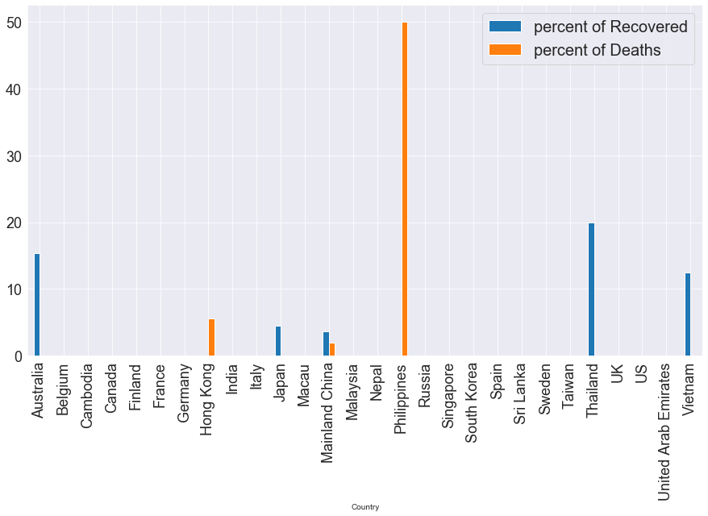

```python
cou.plot("Country",["percent of Recovered","percent of Deaths"],kind='bar',figsize=(15,8), fontsize=18)
plt.legend(fontsize=20)
```

### 中國各省死亡率分析

```python
def get_ci(N,p):
    lci = (p - 1.96*(((p*(1-p))/N) ** 0.5))*100
    uci = (p + 1.96*(((p*(1-p))/N) ** 0.5))*100
    return str(np.round(lci,3)) + "% - " + str(np.round(uci,3)) + '%'
```

```python
final = df[df.Date==np.max(df.Date)]
final = final.copy()

final['CFR'] = np.round((final.Deaths.values/final.Confirmed.values)*100,3)
final['CFR 95% CI'] = final.apply(lambda row: get_ci(row['Confirmed'],row['CFR']/100),axis=1)
global_cfr = np.round(np.sum(final.Deaths.values)/np.sum(final.Confirmed.values)*100, 3)
final = final[final['Country']=='Mainland China']
```

```
No handles with labels found to put in legend.
```

```
Average CFR % = 2.008
```

[figure not shown]

```python
tops = final.sort_values('CFR', ascending= False)
tops = tops[tops.CFR >0]
df2 = final[final['CFR'] != 0]
plt.rcParams["figure.figsize"] = (12,8)
ax = sns.barplot(y="CFR", x="Province/State", order = tops['Province/State'], data=df2, ci=None)
ax.axhline(global_cfr, alpha=.5, color='r', linestyle='dashed')
ax.set_title('Case Fatality Rates (CFR) as of 30 Jan 2020',fontsize=20)
ax.set_ylabel('CFR %',fontsize=20)
ax.set_xlabel('Province/State',fontsize=20)
ax.legend(fontsize=20)
plt.xticks(fontsize=15)
plt.yticks(fontsize=15)

print('Average CFR % = ' + str(global_cfr))
```

### Heat map 分析 (by country and state)

```
No handles with labels found to put in legend.
```

[figure not shown]

```python
fp = data_2_feb.pivot_table(index = 'Province/State', columns = 'Country', values = 'Confirmed')
plt.figure(figsize=(20, 15))
plt.legend(fontsize=20)
plt.title("Deaths per/day",fontsize=20)
plt.xlabel('Date', fontsize=18)
plt.ylabel('Deaths', fontsize=18)
plt.xticks(fontsize=18)
plt.yticks(fontsize=18)
sns.heatmap(fp, cmap = 'plasma')
```

### 2. Data Preprocess for Training

```python
Confirmed = df.groupby('Day').sum()['Confirmed']
Deaths = df.groupby('Day').sum()['Deaths']
Recovered = df.groupby('Day').sum()['Recovered']
df1 = pd.DataFrame(data=[Confirmed, Deaths,Recovered])
df1 = df1.T
```

#### 3.1 Data Normalize

```python
def normalize_data(data, scaler, feature_len):
    minmaxscaler = scaler.fit(data)
    normalize_data = minmaxscaler.transform(data)
    return normalize_data
```

```python
from sklearn.preprocessing import MinMaxScaler

scaler = MinMaxScaler(feature_range=(0, 1))
data = normalize_data(df1, scaler,df.shape[1])
```

#### 3.2 Split Data to Training & Validation

```python
# 前三筆預測後4筆資料
```

```python
def load_data(data, time_step=2, after_day=1, validate_percent=0.67):
    seq_length = time_step + after_day
    result = []
    for index in range(len(data) - seq_length + 1):
        result.append(data[index: index + seq_length])
    result = np.array(result)
    print('total data: ', result.shape)

    train_size = int(len(result) * validate_percent)
    train = result[:train_size, :]
    validate = result[train_size:, :]

    x_train = train[:, :time_step]
    y_train = train[:, time_step:]
    x_validate = validate[:, :time_step]
    y_validate = validate[:, time_step:]

    return [x_train, y_train, x_validate, y_validate]
```

```python
x_train, y_train, x_validate, y_validate = load_data(data,time_step=3, after_day=4, validate_percent=0.5)
```

```
total data:  (8, 7, 3)
```

```python
print('train data: ', x_train.shape, y_train.shape)
print('validate data: ', x_validate.shape, y_validate.shape)
```

```
train data:  (4, 3, 3) (4, 4, 3)
validate data:  (4, 3, 3) (4, 4, 3)
```

```python
x_train
```

```
array([[[0.        , 0.        , 0.        ],
        [0.0040922 , 0.03658537, 0.03337041],
        [0.01611826, 0.05284553, 0.04004449]],

       [[0.0040922 , 0.03658537, 0.03337041],
        [0.01611826, 0.05284553, 0.04004449],
        [0.06113245, 0.11382114, 0.05450501]],

       [[0.01611826, 0.05284553, 0.04004449],
        [0.06113245, 0.11382114, 0.05450501],
        [0.09349424, 0.16260163, 0.06006674]],

       [[0.06113245, 0.11382114, 0.05450501],
        [0.09349424, 0.16260163, 0.06006674],
        [0.16360448, 0.21747967, 0.07007786]]])
```

### 4. Model Training

Predict model: **Seq2Seq** with **LSTM**

[figure not shown]

```python
from random import randint
from numpy import array
from numpy import argmax
from numpy import array_equal
from keras.utils import to_categorical
from keras.models import Sequential, load_model, Model
from keras.layers import Input
from keras.layers import LSTM, Dense, Activation, TimeDistributed, Dropout, Lambda, RepeatVector, Input, Reshape
from keras.layers import Dense
from keras import backend as K
from keras.callbacks import ModelCheckpoint
```

```python
def seq2seq(feature_len=1, after_day=1, input_shape=(8, 1)):
    '''
    Encoder:
    X = Input sequence
    C = LSTM(X); The context vector
    Decoder:
    y(t) = LSTM(s(t-1), y(t-1)); where s is the hidden state of the LSTM(h and c)
    y(0) = LSTM(s0, C); C is the context vector from the encoder.
    '''
    # Encoder
    encoder_inputs = Input(shape=input_shape) # (timesteps, feature)
    encoder = LSTM(units=100, return_state=True,  name='encoder')
    encoder_outputs, state_h, state_c = encoder(encoder_inputs)
    states = [state_h, state_c]

    # Decoder
    reshapor = Reshape((1, 100), name='reshapor')
    decoder = LSTM(units=100, return_sequences=True, return_state=True, name='decoder')

    # Densor
    #tdensor = TimeDistributed(Dense(units=200, activation='linear', name='time_densor'))
    densor_output = Dense(units=feature_len, activation='linear', name='output')

    inputs = reshapor(encoder_outputs)
    #inputs = tdensor(inputs)
    all_outputs = []

    for _ in range(after_day):
        outputs, h, c = decoder(inputs, initial_state=states)

        #inputs = tdensor(outputs)
        inputs = outputs
        states = [state_h, state_c]

        outputs = densor_output(outputs)
        all_outputs.append(outputs)

    decoder_outputs = Lambda(lambda x: K.concatenate(x, axis=1))(all_outputs)
    model = Model(inputs=encoder_inputs, outputs=decoder_outputs)

    return model
```

### 4.1 Architecture

```python
# model complie
input_shape = (3, data.shape[1])
model = seq2seq(data.shape[1], 4, input_shape)
model.compile(loss='mse', optimizer='adam',metrics=['acc'])
model.summary()
```

```
Model: "model_2"
__________________________________________________________________________________________________
Layer (type)                    Output Shape         Param #     Connected to
==================================================================================================
input_2 (InputLayer)            (None, 3, 3)         0
__________________________________________________________________________________________________
encoder (LSTM)                  [(None, 100), (None, 41600       input_2[0][0]
__________________________________________________________________________________________________
reshapor (Reshape)              (None, 1, 100)       0           encoder[0][0]
__________________________________________________________________________________________________
decoder (LSTM)                  [(None, 1, 100), (No 80400       reshapor[0][0]
                                                                 encoder[0][1]
                                                                 encoder[0][2]
                                                                 decoder[0][0]
                                                                 encoder[0][1]
                                                                 encoder[0][2]
                                                                 decoder[1][0]
                                                                 encoder[0][1]
                                                                 encoder[0][2]
                                                                 decoder[2][0]
                                                                 encoder[0][1]
                                                                 encoder[0][2]
__________________________________________________________________________________________________
output (Dense)                  (None, 1, 3)         303         decoder[0][0]
                                                                 decoder[1][0]
                                                                 decoder[2][0]
                                                                 decoder[3][0]
__________________________________________________________________________________________________
lambda_2 (Lambda)               (None, 4, 3)         0           output[0][0]
                                                                 output[1][0]
                                                                 output[2][0]
                                                                 output[3][0]
==================================================================================================
Total params: 122,303
Trainable params: 122,303
Non-trainable params: 0
__________________________________________________________________________________________________
```

### 4.2 Training process

```python
history = model.fit(x_train, y_train, batch_size=3, epochs=50)
```

```python
fontsize=20
def show_train_history(train_history, train, loss):
    plt.plot(train_history.history[train])
    plt.plot(train_history.history[loss])
    plt.title('Train History', fontsize=fontsize)
    plt.ylabel(train, fontsize=fontsize)
    plt.xlabel('Epoch', fontsize=fontsize)
    plt.tick_params(axis='y',labelsize=20)
    plt.tick_params(axis='x',labelsize=20)
    plt.legend(['train','loss'], loc='upper left', fontsize=fontsize) #設定顯示標題於左上角
    plt.show()
```

### 4.3 Training Result

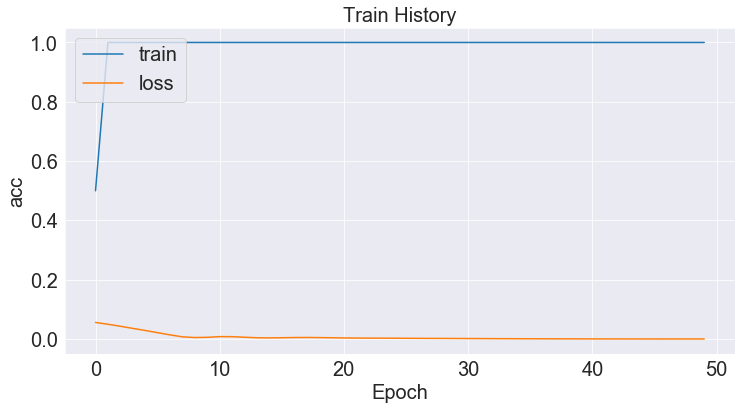

```python
plt.figure(figsize=(12,6))
show_train_history(history,'acc','loss')
```

### 4.4 Training & Validation Result

```python
import math
print('-' * 100)
train_score = model.evaluate(x=x_train, y=y_train, batch_size=3, verbose=0)
print('Train Score: %.8f MSE (%.8f RMSE ) , %.8f  ACC' % (train_score[0], math.sqrt(train_score[0]),train_score[1]*100)  )

validate_score = model.evaluate(x=x_validate, y=y_validate, batch_size=3, verbose=0)
print('Validation Score: %.8f MSE (%.8f RMSE ) , %.8f  ACC' % (validate_score[0], math.sqrt(validate_score[0]),validate_score[1]*100))
```

```
----------------------------------------------------------------------------------------------------
Train Score: 0.00032218 MSE (0.01794936 RMSE ) , 100.00000000  ACC
Validation Score: 0.01944588 MSE (0.13944847 RMSE ) , 93.75000000  ACC
```

### 5. Prediction

### 5.1 Training model with all sample

```python
x_train, y_train, x_validate, y_validate = load_data(data,time_step=3, after_day=4, validate_percent=1)
```

```
total data:  (8, 7, 3)
```

```python
history = model.fit(x_train, y_train, batch_size=3, epochs=50)
```

```python
import math
print('-' * 100)
train_score = model.evaluate(x=x_train, y=y_train, batch_size=3, verbose=0)
print('Train Score: %.8f MSE (%.8f RMSE ) , %.8f  ACC' % (train_score[0], math.sqrt(train_score[0]),train_score[1]*100)  )
```

```
----------------------------------------------------------------------------------------------------
Train Score: 0.00038262 MSE (0.01956061 RMSE ) , 100.00000000  ACC
```

```python
a = model.predict(x_train[7].reshape(1,3,3))
ai = pd.DataFrame(a.reshape(4,3))
bi = pd.DataFrame(a.reshape(4,3)).loc[0:2]
```

```python
def pred(x):
    a = model.predict(x)
    b = pd.DataFrame(a.reshape(4,3)).loc[0:2]
    c = pd.DataFrame(a.reshape(4,3)).loc[1:3]
    return b,c
```

```python
for i in range(3):
    bi,c = pred(bi.values.reshape(1,3,3))
    #print(bi)
    ai = pd.concat([ai,c],axis=0)
```

```python
def inverse_normalize_data(data, scaler):
    for i in range(len(data)):
        data[i] = scaler.inverse_transform(data[i])
    return data
```

```python
train_predict = inverse_normalize_data(ai.values.reshape(1,13,3), scaler)
```

```python
pred_result = pd.DataFrame(train_predict.reshape(13,3)).loc[4:]
pred_result.columns = ['Confirmed','Deaths','Recovered']
pred_result2 = pd.concat([df1,pred_result],axis=0)
pred_result2.Confirmed = pred_result2.Confirmed.apply(lambda x : np.round(x,0))
pred_result2.Deaths = pred_result2.Deaths.apply(lambda x : np.round(x,0))
pred_result2.Recovered = pred_result2.Recovered.apply(lambda x : np.round(x,0))
pred_result2.Confirmed = pred_result2.Confirmed.apply(lambda x : np.int(x,))
pred_result2.Deaths = pred_result2.Deaths.apply(lambda x : np.int(x,))
pred_result2.Recovered = pred_result2.Recovered.apply(lambda x : np.int(x,))
```

```python
next_confirmed=pred_result2.iloc[:, [0]].values.reshape(pred_result2.shape[0],)
BACK_confirmed=df1.iloc[:, [0]].values.reshape(df1.shape[0],)
```

### 5.2 Prediction Result

- The infection forecast for the next three days is **28348**, **33723**, **37397** (2/6,2/7,2/8)
- The actual number of people infected with the 2019-nCoV in the world will reach **50,000 at 02/13**

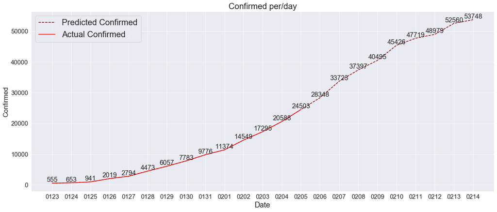

```python
day = ['0123','0124','0125','0126','0127','0128','0129','0130','0131'
       ,'0201','0202','0203','0204','0205','0206','0207','0208','0209','0210'
       ,'0211','0212','0213','0214']
#dfx = pd.DataFrame(data=[y_validate[:], validate_predict])
#dfx = dfx.T
#dfx
plt.figure(figsize=(20, 8))
plt.plot(day,next_confirmed,color='maroon',ls='--',clip_on=True,label='Predicted Confirmed')
plt.plot(BACK_confirmed,color='red',clip_on=True,label='Actual Confirmed')
plt.legend(fontsize=20)
plt.title("Confirmed per/day",fontsize=20)
plt.xlabel('Date', fontsize=18)
plt.ylabel('Confirmed', fontsize=16)
plt.xticks(fontsize=15)
plt.yticks(fontsize=15)

for a, b in zip(day, next_confirmed):
    plt.text(a, b, b, ha='center', va='bottom', fontsize=16)

plt.show()
```

### Referrence:

- Joseph T Wu, Kathy Leung, Gabriel M Leung, "Nowcasting and forecasting the potential domestic and international spread of the 2019-nCoV outbreak originating in Wuhan, China: a modelling study", Jan, 2020 https://www.thelancet.com/journals/lancet/article/PIIS0140-6736(20)30260-9/fulltext?fbclid=IwAR2Mx2VD5_Q4uep_kXAw3bvhN9lhiMKmuRECW6kUZhBrfRHhU0tykZGrksQ
- Al Kahlout RA, Nasrallah GK, Farag EA, et al., " Comparative serological study for the prevalence of anti-MERS coronavirus antibodies in high-and low-risk groups in Qatar. ", J Immunol Res. 2019; (published online Feb 18. DOI:10.1155/2019/1386740.)
- Zhao S, Ran J, Musa SS, et al., " Preliminary estimation of the basic reproduction number of novel coronavirus (2019-nCoV) in China, from 2019 to 2020: a data-driven analysis in the early phase of the outbreak. ", bioRxiv. 2020; (published online Jan 24. DOI:10.1101/2020.01.23.916395 (preprint).)
- https://datastudio.google.com/embed/reporting/c84945c0-21a5-42ee-bd79-e6e02dfa43c6/page/eHUDB
- https://kiang.github.io/2019-nCoV/